# 英国食品安全干预措施成功率分析

王天翼

# 介绍

该项目的[数据](https://www.data.gov.uk/dataset/090b5b23-5020-4480-96a0-8b294ca82653/local-authority-food-law-enforcement-returns)来源于英格兰、威尔士和北爱尔兰的地方当局对其管辖范围内的餐饮单位进行的影响力评级。这些评级是根据这些单位对公众健康造成的潜在影响（包括可能引发的疾病的人数和严重程度等）来确定的，评级从 A （潜在影响最大）到 E （潜在影响最小）不等。

在餐饮单位的公众影响力被评级后，地方当局将对其进行检查，以确定它们是否符合卫生和食品安全法规的要求。如果单位未能达到”基本满意”的标准，地方当局将对其进行干预，要求他们纠正问题。如果干预后，单位成功达到了要求，他们将被允许继续运营。

本项目对地方当局干预餐饮单位的成功率进行分析，既考虑了餐饮单位同专业执法人员数量的关系，也考虑了餐饮单位数量与执法人员数量比例对成功率的影响。该分析旨在为地方当局的决策提供依据，以提高整体食品安全水平。

**该项目的报告分为两部分**。第一部分针对数据分析专业人士，详细展现了我们的数据分析过程和结果。第二部分则针对政策制定者，概述了我们的主要发现和建议。我们希望通过这种方式，使得无论读者的背景如何，都能够理解和利用我们的研究成果。

# 第一部分：数据分析和结果

## 数据字典

数据的核心结构如下（完整字典请见附录）：

| 变量名称 | 变量含义 |
| --- | --- |
| LAType | 地方当局的类型 |
| LAName | 地方当局的名称 |
| Totalestablishments(includingnotyetrated&outside) | 截至 2020 年 3 月 31 日，地方当局报告注册（或批准）的餐饮单位数量 |
| Establishmentsnotyetratedforintervention | 尚未进行食品卫生风险评级（如新企业等）的餐饮单位数量 |
| Establishmentsoutsidetheprogramme | 不在《卫生和食品安全法》管辖范围内的餐饮单位数量 |
| Aratedestablishments | 影响力分数大于92的餐饮单位数量，被视为对公共健康的潜在影响力最大，其干预频率至少为每6个月一次 |
| Bratedestablishments | 影响力分数在72到91之间的餐饮单位数量，其干预频率至少为每12个月一次 |
| Cratedestablishments | 影响力分数在52到71之间的餐饮单位数量，其干预频率至少为每18个月一次 |
| Dratedestablishments | 影响力分数在31到51之间的餐饮单位数量，其干预频率至少为每24个月一次 |
| Eratedestablishments | 影响力分数小于30的餐饮单位数量，被视为对公共健康的潜在影响力最小，其干预频率为每3年一次，或采用其他执法措施 |
| Total%ofInterventionsachieved(premisesratedA-E) | 根据《食品卫生干预情况评级》计算出的干预行动完成率 |
| Total%ofInterventionsachieved-premisesratedA | 根据《食品卫生干预情况评级》计算出的针对影响力评级为 A 的单位的干预行动完成率 |
| Total%ofInterventionsachieved-premisesratedB | 根据《食品卫生干预情况评级》计算出的针对影响力评级为 B 的单位的干预行动完成率 |
| Total%ofInterventionsachieved-premisesratedC | 根据《食品卫生干预情况评级》计算出的针对影响力评级为 C 的单位的干预行动完成率 |
| Total%ofInterventionsachieved-premisesratedD | 根据《食品卫生干预情况评级》计算出的针对影响力评级为 D 的单位的干预行动完成率 |
| Total%ofInterventionsachieved-premisesratedE | 根据《食品卫生干预情况评级》计算出的针对影响力评级为 E 的单位的干预行动完成率 |
| ProfessionalFullTimeEquivalentPosts-occupied * | 在食品卫生方面的执法人员数量 |

## 读取食品卫生数据

```r
# 导入数据
food_data <- read_csv("2019-20-enforcement-data-food-hygiene.csv")

# 了解数据结构，选择感兴趣的变量
str(food_data[,c(1,2,4,19:25,36)])
```

```
## tibble [353 × 11] (S3: tbl_df/tbl/data.frame)
##  $ Country                                          : chr [1:353] "England" "England" "England" "England" ...
##  $ LAType                                           : chr [1:353] "District Council" "District Council" "District Council" "District Council" ...
##  $ Totalestablishments(includingnotyetrated&outside): num [1:353] 1478 1316 1112 1208 905 ...
##  $ Total%ofInterventionsachieved(premisesratedA-E)  : num [1:353] 96.1 90.6 88.9 94 80.7 ...
##  $ Total%ofInterventionsachieved-premisesratedA     : chr [1:353] "100" "100" "100" "100" ...
##  $ Total%ofInterventionsachieved-premisesratedB     : num [1:353] 100 98.3 95.1 96.3 100 ...
##  $ Total%ofInterventionsachieved-premisesratedC     : num [1:353] 95.5 89.7 97 94.4 78.8 ...
##  $ Total%ofInterventionsachieved-premisesratedD     : num [1:353] 96 93 91.8 92.6 85.3 ...
##  $ Total%ofInterventionsachieved-premisesratedE     : num [1:353] 94 85.1 72.3 95.5 68.3 ...
##  $ Total%ofInterventionsachieved-premisesnotyetrated: num [1:353] 100 100 100 95.4 79.6 ...
##  $ ProfessionalFullTimeEquivalentPosts-occupied *   : num [1:353] 5 4 3.5 4 2 4.65 2.5 5 2 4.2 ...
```

## 数据清洗

根据 LAEMS 2019-2020 年度数据，6 个地方当局的食品卫生调查报告未能及时提供。因此，我们删除了这 6 条数据。

**数据修正**：总共有 52 个地方当局不存在 A 级影响力的餐饮单位。因此这些地方“对 A 级影响力餐饮单位进行成功干预的百分比”应为 “NR”，即没有应采取或报告的干预措施，而不是 部分数据中所呈现的 100。此外，为了数据处理的需要，我们将所有 “NR” 值改为空值。

```r
# 删除 6 份未提交的报告数据
food_data <- filter(food_data,is.na(`Totalestablishments(includingnotyetrated&outside)`)==FALSE)

# 对于被评为 A 级的企业，应采取的干预措施应为 0
# 因此，“已采取干预措施的百分比”项应注明为 "NR"，即没有应采取或报告的干预措施
filter(food_data[,c(3,9,10,20)],Aratedestablishments==0)
```

```
## # A tibble: 52 × 4
##    LAName                Aratedestablishments Total%ofBroadlyCompliantestab…¹ Total%ofIntervention…²
##    <chr>                                <dbl> <chr>                           <chr>
##  1 Basingstoke and Deane                    0 NP                              100
##  2 Bolsover                                 0 NP                              100
##  3 Bromsgrove                               0 NP                              100
##  4 Carlisle City                            0 NP                              100
##  5 Chelmsford                               0 NP                              100
##  6 Cheltenham                               0 NP                              100
##  7 Corby                                    0 NP                              100
##  8 East Dorset (1)                          0 NP                              100
##  9 East Northamptonshire                    0 NP                              NR
## 10 East Staffordshire                       0 NP                              NR
## # ℹ 42 more rows
## # ℹ abbreviated names: ¹`Total%ofBroadlyCompliantestablishments-A`,
## #   ²`Total%ofInterventionsachieved-premisesratedA`
```

```r
food_data$`Total%ofInterventionsachieved-premisesratedA`[which(food_data$Aratedestablishments==0)] <- 'NR'
```

```r
# 根据我们的需要转换变量类型
food_data$`Total%ofInterventionsachieved-premisesratedA`[which(food_data$`Total%ofInterventionsachieved-premisesratedA`=='NR')] <- ''
food_data$Country <- as.factor(food_data$Country)
food_data$LAType <- as.factor(food_data$LAType)
food_data$`Total%ofInterventionsachieved-premisesratedA` <- as.numeric(food_data$`Total%ofInterventionsachieved-premisesratedA`)
food_data$`Total%ofBroadlyCompliantestablishments-A` <- as.numeric(food_data$`Total%ofBroadlyCompliantestablishments-A`)

summary(food_data[,c(4,19:25,36)])
```

```
##  Totalestablishments(includingnotyetrated&outside) Total%ofInterventionsachieved(premisesratedA-E)
##  Min.   : 145.0                                    Min.   : 20.64
##  1st Qu.: 920.5                                    1st Qu.: 81.81
##  Median :1330.0                                    Median : 90.82
##  Mean   :1620.7                                    Mean   : 86.62
##  3rd Qu.:2004.5                                    3rd Qu.: 95.39
##  Max.   :9277.0                                    Max.   :100.00
##
##  Total%ofInterventionsachieved-premisesratedA Total%ofInterventionsachieved-premisesratedB
##  Min.   : 33.33                               Min.   : 50.00
##  1st Qu.:100.00                               1st Qu.: 93.53
##  Median :100.00                               Median : 97.75
##  Mean   : 97.86                               Mean   : 95.25
##  3rd Qu.:100.00                               3rd Qu.:100.00
##  Max.   :100.00                               Max.   :100.00
##  NA's   :57
##  Total%ofInterventionsachieved-premisesratedC Total%ofInterventionsachieved-premisesratedD
##  Min.   : 18.37                               Min.   : 19.77
##  1st Qu.: 89.27                               1st Qu.: 82.00
##  Median : 94.97                               Median : 91.72
##  Mean   : 91.84                               Mean   : 86.32
##  3rd Qu.: 97.77                               3rd Qu.: 95.98
##  Max.   :100.00                               Max.   :100.00
##
##  Total%ofInterventionsachieved-premisesratedE Total%ofInterventionsachieved-premisesnotyetrated
##  Min.   :  1.81                               Min.   :  6.56
##  1st Qu.: 65.39                               1st Qu.: 85.81
##  Median : 87.50                               Median : 99.75
##  Mean   : 77.37                               Mean   : 90.95
##  3rd Qu.: 95.90                               3rd Qu.:100.00
##  Max.   :100.00                               Max.   :100.00
##
##  ProfessionalFullTimeEquivalentPosts-occupied *
##  Min.   : 0.65
##  1st Qu.: 2.50
##  Median : 3.41
##  Mean   : 4.10
##  3rd Qu.: 5.00
##  Max.   :22.13
##
```

至此，数据预处理步骤已完成，可以进行下一步的分析。

## 干预成功率分布图

包含 A-E 级影响力评级的整体干预成功率如下：

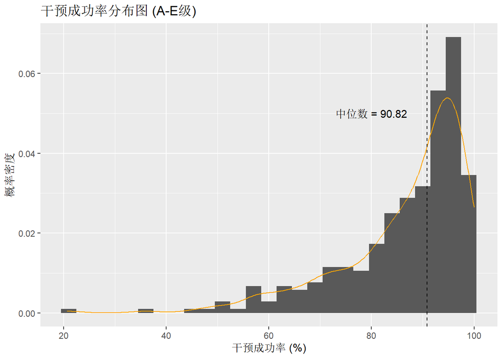

```r
plot1 <- ggplot(food_data,aes(x=`Total%ofInterventionsachieved(premisesratedA-E)`,y=..density..))+geom_histogram(binwidth=3)+
  geom_density(col="orange")+geom_vline(xintercept = median(food_data$`Total%ofInterventionsachieved(premisesratedA-E)`),linetype="dashed")+
  labs(x="干预成功率 (%)",y="概率密度",title = "干预成功率分布图 (A-E级)")+
  annotate("text",x=80,y=0.05,
           label=paste("中位数 =",round(median(food_data$`Total%ofInterventionsachieved(premisesratedA-E)`),2)))

plot1
```

不同影响力的干预成功率分布图分别如下：

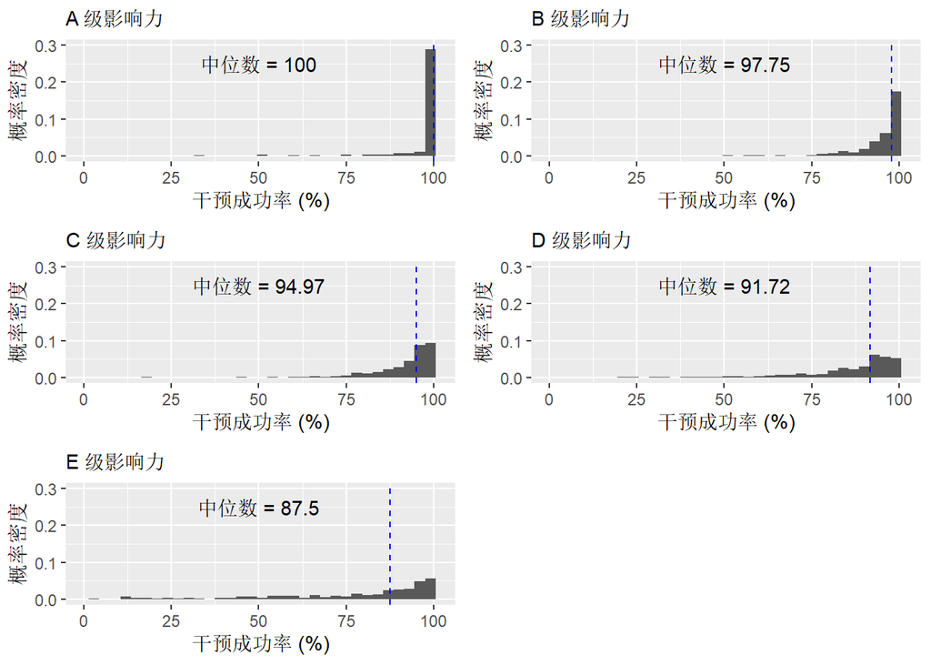

```r
plot2 <- ggarrange(
ggplot(food_data,aes(x=`Total%ofInterventionsachieved-premisesratedA`,y=..density..))+geom_histogram(binwidth=3)+
  labs(x="干预成功率 (%)",y="概率密度",subtitle = "A 级影响力")+ylim(0,0.3)+xlim(0,101)+
  geom_vline(xintercept = median(food_data$`Total%ofInterventionsachieved-premisesratedA`,na.rm=T),lty="dashed",col="blue")+
  annotate("text",x=50,y=0.25,
           label=paste("中位数 =",round(median(food_data$`Total%ofInterventionsachieved-premisesratedA`,na.rm=T),2))),

ggplot(food_data,aes(x=`Total%ofInterventionsachieved-premisesratedB`,y=..density..))+geom_histogram(binwidth=3)+
  labs(x="干预成功率 (%)",y="概率密度",subtitle = "B 级影响力")+ylim(0,0.3)+xlim(0,101)+
  geom_vline(xintercept = median(food_data$`Total%ofInterventionsachieved-premisesratedB`,na.rm=T),lty="dashed",col="blue")+
  annotate("text",x=50,y=0.25,
           label=paste("中位数 =",round(median(food_data$`Total%ofInterventionsachieved-premisesratedB`,na.rm=T),2))),

ggplot(food_data,aes(x=`Total%ofInterventionsachieved-premisesratedC`,y=..density..))+geom_histogram(binwidth=3)+
  labs(x="干预成功率 (%)",y="概率密度",subtitle = "C 级影响力")+ylim(0,0.3)+xlim(0,101)+
  geom_vline(xintercept = median(food_data$`Total%ofInterventionsachieved-premisesratedC`,na.rm=T),lty="dashed",col="blue")+
  annotate("text",x=50,y=0.25,
           label=paste("中位数 =",round(median(food_data$`Total%ofInterventionsachieved-premisesratedC`,na.rm=T),2))),

ggplot(food_data,aes(x=`Total%ofInterventionsachieved-premisesratedD`,y=..density..))+geom_histogram(binwidth=3)+
  labs(x="干预成功率 (%)",y="概率密度",subtitle = "D 级影响力")+ylim(0,0.3)+xlim(0,101)+
  geom_vline(xintercept = median(food_data$`Total%ofInterventionsachieved-premisesratedD`,na.rm=T),lty="dashed",col="blue")+
  annotate("text",x=50,y=0.25,
           label=paste("中位数 =",round(median(food_data$`Total%ofInterventionsachieved-premisesratedD`,na.rm=T),2))),

ggplot(food_data,aes(x=`Total%ofInterventionsachieved-premisesratedE`,y=..density..))+geom_histogram(binwidth=3)+
  labs(x="干预成功率 (%)",y="概率密度",subtitle = "E 级影响力")+ylim(0,0.3)+xlim(0,101)+
  geom_vline(xintercept = median(food_data$`Total%ofInterventionsachieved-premisesratedE`,na.rm=T),lty="dashed",col="blue")+
  annotate("text",x=50,y=0.25,
           label=paste("中位数 =",round(median(food_data$`Total%ofInterventionsachieved-premisesratedE`,na.rm=T),2))),
ncol=2,nrow=3)

plot2
```

## 执法人员数量与干预成功率的关系图

本部分使用散点图和箱型图来显示执法人员数量与干预成功率之间的关系，如下所示：

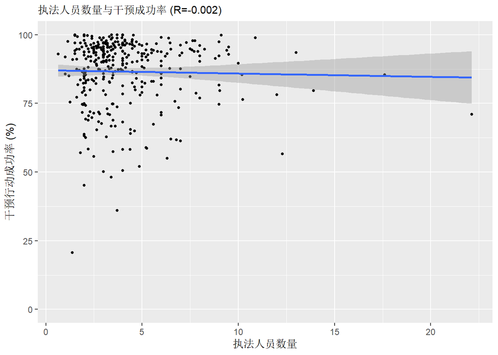

```r
plot3 <- ggplot(food_data,aes(y=`Total%ofInterventionsachieved(premisesratedA-E)`,x=`ProfessionalFullTimeEquivalentPosts-occupied *`))+
  geom_point(size=1)+geom_smooth(method = "lm")+
  labs(x="执法人员数量",y="干预行动成功率 (%)",subtitle = "执法人员数量与干预成功率 (R=-0.002)")+ylim(0,100)

plot3
```

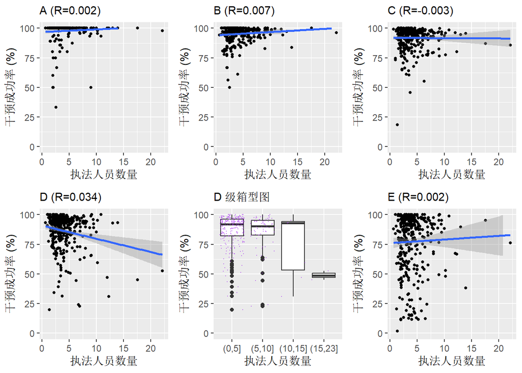

```r
food_data$FTE <- cut(food_data$`ProfessionalFullTimeEquivalentPosts-occupied *`,breaks = c(0,5,10,15,23))

plot4 <- ggarrange(

  ggplot(food_data,aes(y=`Total%ofInterventionsachieved-premisesratedA`,x=`ProfessionalFullTimeEquivalentPosts-occupied *`))+
  geom_point(size=1)+geom_smooth(method = "lm")+
  labs(x="执法人员数量",y="干预成功率 (%)",subtitle = "A (R=0.002)")+ylim(0,100),

  ggplot(food_data,aes(y=`Total%ofInterventionsachieved-premisesratedB`,x=`ProfessionalFullTimeEquivalentPosts-occupied *`))+
  geom_point(size=1)+geom_smooth(method = "lm")+
  labs(x="执法人员数量",y="干预成功率 (%)",subtitle = "B (R=0.007)")+ylim(0,100),

  ggplot(food_data,aes(y=`Total%ofInterventionsachieved-premisesratedC`,x=`ProfessionalFullTimeEquivalentPosts-occupied *`))+
  geom_point(size=1)+geom_smooth(method = "lm")+
  labs(x="执法人员数量",y="干预成功率 (%)",subtitle = "C (R=-0.003)")+ylim(0,100),

  ggplot(food_data,aes(y=`Total%ofInterventionsachieved-premisesratedD`,x=`ProfessionalFullTimeEquivalentPosts-occupied *`))+
  geom_point(size=1)+geom_smooth(method = "lm")+
  labs(x="执法人员数量",y="干预成功率 (%)",subtitle = "D (R=0.034)")+ylim(0,100),

  ggplot(food_data,aes(x=FTE,y=`Total%ofInterventionsachieved-premisesratedD`))+geom_boxplot()+
  geom_jitter(width = 0.4,size=0.05,alpha=0.5,col="purple")+
  labs(x="执法人员数量",y="干预成功率 (%)",subtitle = "D 级箱型图")+ylim(0,100),

  ggplot(food_data,aes(y=`Total%ofInterventionsachieved-premisesratedE`,x=`ProfessionalFullTimeEquivalentPosts-occupied *`))+
  geom_point(size=1)+geom_smooth(method = "lm")+
  labs(x="执法人员数量",y="干预成功率 (%)",subtitle = "E (R=0.002)")+ylim(0,100))

plot4
```

在进行回归之前，让我们先检查一下执法人员数量与干预成功率之间的相关性：

```r
correlation_table <- data.frame(Variable=names(food_data[,c(19:24)]),Coefficient=NA,P_value=NA)
correlation_table$Coefficient <- rcorr(as.matrix(food_data[,c(19:24,36)]), type = "spearman")$r[1:6,7]
correlation_table$P_value <-rcorr(as.matrix(food_data[,c(19:24,36)]), type = "spearman")$P[1:6,7]

correlation_table
```

```
##                                          Variable  Coefficient   P_value
## 1 Total%ofInterventionsachieved(premisesratedA-E) -0.001545684 0.9771126
## 2    Total%ofInterventionsachieved-premisesratedA  0.007581317 0.8977142
## 3    Total%ofInterventionsachieved-premisesratedB  0.041845682 0.4371432
## 4    Total%ofInterventionsachieved-premisesratedC -0.047900006 0.3736972
## 5    Total%ofInterventionsachieved-premisesratedD -0.092541505 0.0851905
## 6    Total%ofInterventionsachieved-premisesratedE  0.027034082 0.6157633
```

根据需要，我们进行简单的线性回归，并将其汇总为下面的回归表：

```r
summary(lm(`Total%ofInterventionsachieved(premisesratedA-E)`~`ProfessionalFullTimeEquivalentPosts-occupied *`,food_data))
```

```
##
## Call:
## lm(formula = `Total%ofInterventionsachieved(premisesratedA-E)` ~
##     `ProfessionalFullTimeEquivalentPosts-occupied *`, data = food_data)
##
## Residuals:
##     Min      1Q  Median      3Q     Max
## -66.304  -4.575   4.067   8.658  13.860
##
## Coefficients:
##                                                  Estimate Std. Error t value Pr(>|t|)
## (Intercept)                                       87.1091     1.2828  67.905   <2e-16 ***
## `ProfessionalFullTimeEquivalentPosts-occupied *`  -0.1195     0.2675  -0.447    0.655
## ---
## Signif. codes:  0 '***' 0.001 '**' 0.01 '*' 0.05 '.' 0.1 ' ' 1
##
## Residual standard error: 12.4 on 345 degrees of freedom
## Multiple R-squared:  0.0005787,  Adjusted R-squared:  -0.002318
## F-statistic: 0.1998 on 1 and 345 DF,  p-value: 0.6552
```

```r
summary(lm(`Total%ofInterventionsachieved-premisesratedA`~`ProfessionalFullTimeEquivalentPosts-occupied *`,food_data))
```

```
##
## Call:
## lm(formula = `Total%ofInterventionsachieved-premisesratedA` ~
##     `ProfessionalFullTimeEquivalentPosts-occupied *`, data = food_data)
##
## Residuals:
##     Min      1Q  Median      3Q     Max
## -64.136   1.683   2.228   2.446   2.959
##
## Coefficients:
##                                                  Estimate Std. Error t value Pr(>|t|)
## (Intercept)                                       96.8993     0.9140 106.016   <2e-16 ***
## `ProfessionalFullTimeEquivalentPosts-occupied *`   0.2181     0.1791   1.218    0.224
## ---
## Signif. codes:  0 '***' 0.001 '**' 0.01 '*' 0.05 '.' 0.1 ' ' 1
##
## Residual standard error: 7.882 on 288 degrees of freedom
##   (因为不存在，57个观察量被删除了)
## Multiple R-squared:  0.005122,   Adjusted R-squared:  0.001668
## F-statistic: 1.483 on 1 and 288 DF,  p-value: 0.2243
```

```r
summary(lm(`Total%ofInterventionsachieved-premisesratedB`~`ProfessionalFullTimeEquivalentPosts-occupied *`,food_data))
```

```
##
## Call:
## lm(formula = `Total%ofInterventionsachieved-premisesratedB` ~
##     `ProfessionalFullTimeEquivalentPosts-occupied *`, data = food_data)
##
## Residuals:
##     Min      1Q  Median      3Q     Max
## -44.815  -1.805   2.418   4.533   5.593
##
## Coefficients:
##                                                  Estimate Std. Error t value Pr(>|t|)
## (Intercept)                                       94.1355     0.7040 133.711   <2e-16 ***
## `ProfessionalFullTimeEquivalentPosts-occupied *`   0.2717     0.1468   1.851    0.065 .
## ---
## Signif. codes:  0 '***' 0.001 '**' 0.01 '*' 0.05 '.' 0.1 ' ' 1
##
## Residual standard error: 6.804 on 345 degrees of freedom
## Multiple R-squared:  0.009833,   Adjusted R-squared:  0.006963
## F-statistic: 3.426 on 1 and 345 DF,  p-value: 0.06503
```

```r
summary(lm(`Total%ofInterventionsachieved-premisesratedC`~`ProfessionalFullTimeEquivalentPosts-occupied *`,food_data))
```

```
##
## Call:
## lm(formula = `Total%ofInterventionsachieved-premisesratedC` ~
##     `ProfessionalFullTimeEquivalentPosts-occupied *`, data = food_data)
##
## Residuals:
##     Min      1Q  Median      3Q     Max
## -73.538  -2.617   3.183   5.963   8.168
##
## Coefficients:
##                                                  Estimate Std. Error t value Pr(>|t|)
## (Intercept)                                      91.94143    0.96000   95.77   <2e-16 ***
## `ProfessionalFullTimeEquivalentPosts-occupied *` -0.02396    0.20016   -0.12    0.905
## ---
## Signif. codes:  0 '***' 0.001 '**' 0.01 '*' 0.05 '.' 0.1 ' ' 1
##
## Residual standard error: 9.277 on 345 degrees of freedom
## Multiple R-squared:  4.152e-05,  Adjusted R-squared:  -0.002857
## F-statistic: 0.01433 on 1 and 345 DF,  p-value: 0.9048
```

```r
summary(lm(`Total%ofInterventionsachieved-premisesratedD`~`ProfessionalFullTimeEquivalentPosts-occupied *`,food_data))
```

```
##
## Call:
## lm(formula = `Total%ofInterventionsachieved-premisesratedD` ~
##     `ProfessionalFullTimeEquivalentPosts-occupied *`, data = food_data)
##
## Residuals:
##     Min      1Q  Median      3Q     Max
## -69.581  -4.915   4.727   9.449  21.225
##
## Coefficients:
##                                                  Estimate Std. Error t value Pr(>|t|)
## (Intercept)                                        90.887      1.468  61.923  < 2e-16 ***
## `ProfessionalFullTimeEquivalentPosts-occupied *`   -1.113      0.306  -3.638 0.000317 ***
## ---
## Signif. codes:  0 '***' 0.001 '**' 0.01 '*' 0.05 '.' 0.1 ' ' 1
##
## Residual standard error: 14.18 on 345 degrees of freedom
## Multiple R-squared:  0.03694,    Adjusted R-squared:  0.03415
## F-statistic: 13.23 on 1 and 345 DF,  p-value: 0.0003171
```

```r
summary(lm(`Total%ofInterventionsachieved-premisesratedE`~`ProfessionalFullTimeEquivalentPosts-occupied *`,food_data))
```

```
##
## Call:
## lm(formula = `Total%ofInterventionsachieved-premisesratedE` ~
##     `ProfessionalFullTimeEquivalentPosts-occupied *`, data = food_data)
##
## Residuals:
##     Min      1Q  Median      3Q     Max
## -74.724 -12.405   9.929  18.679  23.582
##
## Coefficients:
##                                                  Estimate Std. Error t value Pr(>|t|)
## (Intercept)                                       76.1117     2.4930  30.530   <2e-16 ***
## `ProfessionalFullTimeEquivalentPosts-occupied *`   0.3063     0.5198   0.589    0.556
## ---
## Signif. codes:  0 '***' 0.001 '**' 0.01 '*' 0.05 '.' 0.1 ' ' 1
##
## Residual standard error: 24.09 on 345 degrees of freedom
## Multiple R-squared:  0.001006,   Adjusted R-squared:  -0.00189
## F-statistic: 0.3474 on 1 and 345 DF,  p-value: 0.556
```

```r
# 由于模型的拟合度过低，通过要求 FTE <= 15 来消除一些可能的异常值
# 再次对 D 级干预的百分比进行回归，查看是否能带来影响
filter(food_data,`ProfessionalFullTimeEquivalentPosts-occupied *`<=15)%>%
  lm(`Total%ofInterventionsachieved-premisesratedD`~`ProfessionalFullTimeEquivalentPosts-occupied *`,.)%>%summary()
```

```
##
## Call:
## lm(formula = `Total%ofInterventionsachieved-premisesratedD` ~
##     `ProfessionalFullTimeEquivalentPosts-occupied *`, data = .)
##
## Residuals:
##     Min      1Q  Median      3Q     Max
## -68.727  -4.483   4.901   9.468  18.574
##
## Coefficients:
##                                                  Estimate Std. Error t value Pr(>|t|)
## (Intercept)                                       89.5238     1.5909  56.273   <2e-16 ***
## `ProfessionalFullTimeEquivalentPosts-occupied *`  -0.7443     0.3487  -2.135   0.0335 *
## ---
## Signif. codes:  0 '***' 0.001 '**' 0.01 '*' 0.05 '.' 0.1 ' ' 1
##
## Residual standard error: 14.11 on 343 degrees of freedom
## Multiple R-squared:  0.01311,    Adjusted R-squared:  0.01023
## F-statistic: 4.557 on 1 and 343 DF,  p-value: 0.03349
```

```r
regression_table <- data.frame(Variable=names(food_data[,c(19:24)]),Estimate=NA,P_value=NA,LowerCI=NA,UpperCI=NA)

regression_table[1,2:3] <- (lm(`Total%ofInterventionsachieved(premisesratedA-E)`~`ProfessionalFullTimeEquivalentPosts-occupied *`,food_data)%>%summary())$coefficients[2,c(1,4)]
regression_table[2,2:3] <- (lm(`Total%ofInterventionsachieved-premisesratedA`~`ProfessionalFullTimeEquivalentPosts-occupied *`,food_data)%>%summary())$coefficients[2,c(1,4)]
regression_table[3,2:3] <- (lm(`Total%ofInterventionsachieved-premisesratedB`~`ProfessionalFullTimeEquivalentPosts-occupied *`,food_data)%>%summary())$coefficients[2,c(1,4)]
regression_table[4,2:3] <- (lm(`Total%ofInterventionsachieved-premisesratedC`~`ProfessionalFullTimeEquivalentPosts-occupied *`,food_data)%>%summary())$coefficients[2,c(1,4)]
regression_table[5,2:3] <- (lm(`Total%ofInterventionsachieved-premisesratedD`~`ProfessionalFullTimeEquivalentPosts-occupied *`,food_data)%>%summary())$coefficients[2,c(1,4)]
regression_table[6,2:3] <- (lm(`Total%ofInterventionsachieved-premisesratedE`~`ProfessionalFullTimeEquivalentPosts-occupied *`,food_data)%>%summary())$coefficients[2,c(1,4)]
regression_table[1,4:5] <- (lm(`Total%ofInterventionsachieved(premisesratedA-E)`~`ProfessionalFullTimeEquivalentPosts-occupied *`,food_data)%>%confint())[2,]
regression_table[2,4:5] <- (lm(`Total%ofInterventionsachieved-premisesratedA`~`ProfessionalFullTimeEquivalentPosts-occupied *`,food_data)%>%confint())[2,]
regression_table[3,4:5] <- (lm(`Total%ofInterventionsachieved-premisesratedB`~`ProfessionalFullTimeEquivalentPosts-occupied *`,food_data)%>%confint())[2,]
regression_table[4,4:5] <- (lm(`Total%ofInterventionsachieved-premisesratedC`~`ProfessionalFullTimeEquivalentPosts-occupied *`,food_data)%>%confint())[2,]
regression_table[5,4:5] <- (lm(`Total%ofInterventionsachieved-premisesratedD`~`ProfessionalFullTimeEquivalentPosts-occupied *`,food_data)%>%confint())[2,]
regression_table[6,4:5] <- (lm(`Total%ofInterventionsachieved-premisesratedE`~`ProfessionalFullTimeEquivalentPosts-occupied *`,food_data)%>%confint())[2,]

regression_table
```

```
##                                          Variable    Estimate      P_value    LowerCI    UpperCI
## 1 Total%ofInterventionsachieved(premisesratedA-E) -0.11954687 0.6551755893 -0.6456029  0.4065092
## 2    Total%ofInterventionsachieved-premisesratedA  0.21806746 0.2243394055 -0.1344105  0.5705454
## 3    Total%ofInterventionsachieved-premisesratedB  0.27169657 0.0650263624 -0.0170094  0.5604025
## 4    Total%ofInterventionsachieved-premisesratedC -0.02395684 0.9047973374 -0.4176349  0.3697212
## 5    Total%ofInterventionsachieved-premisesratedD -1.11320818 0.0003170696 -1.7151046 -0.5113118
## 6    Total%ofInterventionsachieved-premisesratedE  0.30634749 0.5559972652 -0.7160008  1.3286958
```

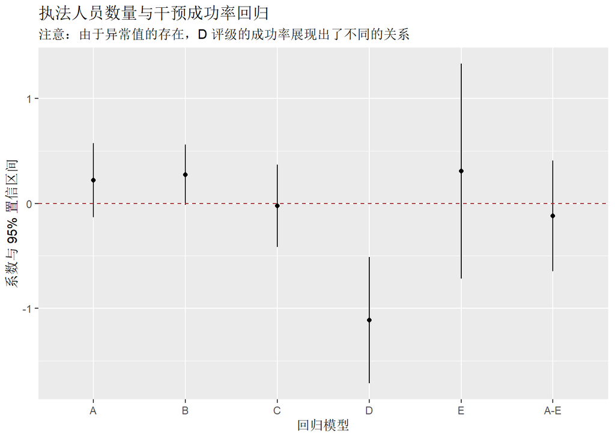

```r
plot5 <- ggplot(regression_table, aes(x=factor(Variable,labels = c("A","B","C","D","E","A-E")),
                              y=Estimate,ymin=LowerCI,ymax=UpperCI))+geom_point()+geom_linerange()+labs(x="回归模型",y="系数与 95% 置信区间",title = "执法人员数量与干预成功率回归",subtitle = "注意：由于异常值的存在，D 评级的成功率展现出了不同的关系")+geom_hline(yintercept = 0,lty="dashed",col="brown")

plot5
```

只有针对 D 评级的执法人员数量对干预效果百分比的影响显著不同于 0，置信区间在 95% 的水平上等于 [-1.72,-0.51]，t(345)=-3.64，P 值小于 0.01。但这可能是由于异常值或/和执法人员数量 > 15 的观测值不足造成的虚假关系。

## 执法人员相对于 1000 家餐饮单位的比例与干预成功率的关系

在之前的步骤中，我们使用每个地方当局的执法人员数量作为变量。但执法人员的数量本身不具备实际含义，它需要与相应的餐饮单位数量进行比较。因此，我们生成“执法人员相对于 1000 家餐饮单位的比例”指标，来判断数量是否相对“多”或“少”。

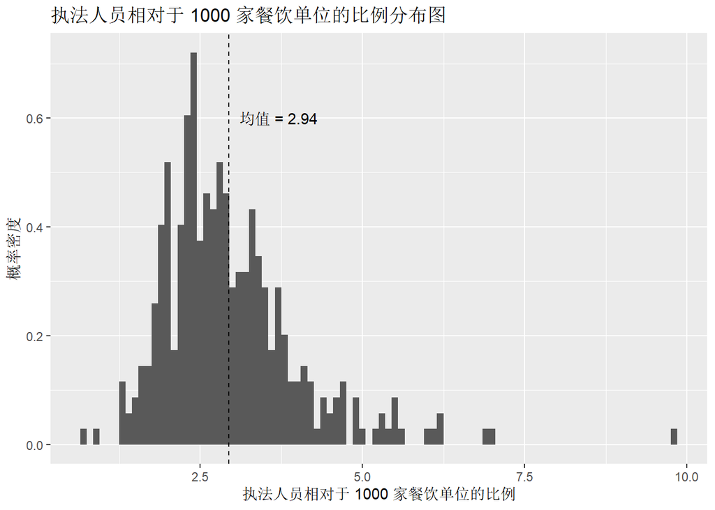

```r
food_data <- mutate(food_data,establishment_number=`Totalestablishments(includingnotyetrated&outside)`-Establishmentsnotyetratedforintervention-Establishmentsoutsidetheprogramme,)

food_data <- mutate(food_data,FTE_per_1000_establishments=food_data$`ProfessionalFullTimeEquivalentPosts-occupied *`/food_data$establishment_number*1000)

# 执法人员相对于 1000 家餐饮单位的比例分布图
ggplot(food_data,aes(x=FTE_per_1000_establishments,y=..density..))+geom_histogram(binwidth = 0.1)+
  labs(x="执法人员相对于 1000 家餐饮单位的比例",y="概率密度",title = "执法人员相对于 1000 家餐饮单位的比例分布图")+
  geom_vline(xintercept = mean(food_data$FTE_per_1000_establishments),linetype="dashed")+
  annotate("text",x=3.7,y=0.6,
           label=paste("均值 =",round(mean(food_data$FTE_per_1000_establishments),2)))
```

直方图中有一个值为 9.77的异常值，我们决定在进一步分析之前将其删除。

```r
# 删除异常值
filter(food_data,FTE_per_1000_establishments>7)$FTE_per_1000_establishments
```

```
## [1] 9.76801
```

```r
food_data <- filter(food_data,FTE_per_1000_establishments<=7)
```

使用散点图和箱型图来直观显示执法人员相对于 1000 家餐饮单位的比例与干预成功率的关系，如下所示：

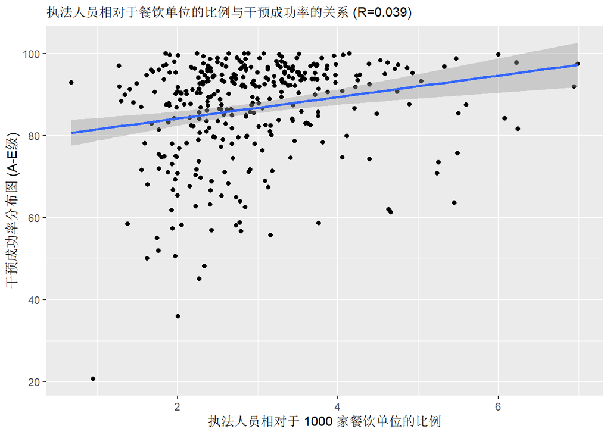

```r
plot6 <- ggplot(food_data,aes(x=FTE_per_1000_establishments ,y=`Total%ofInterventionsachieved(premisesratedA-E)`))+
  geom_point()+geom_smooth(method = "lm")+labs(x="执法人员相对于 1000 家餐饮单位的比例",y="干预成功率分布图 (A-E级)",subtitle = "执法人员相对于餐饮单位的比例与干预成功率的关系 (R=0.039)")

plot6
```

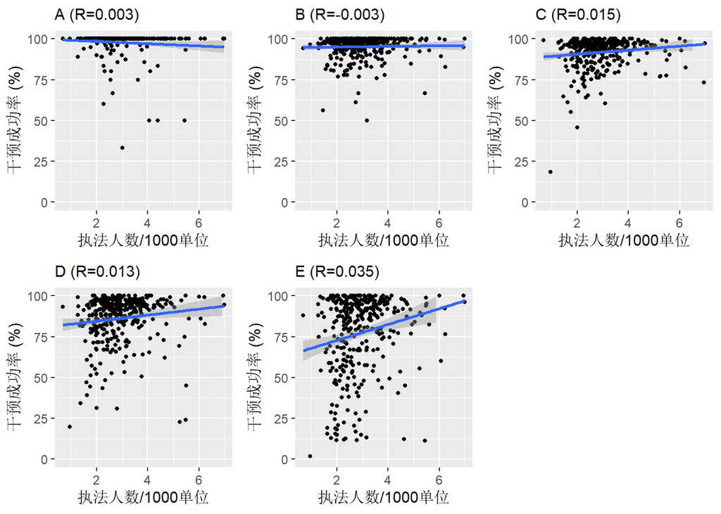

```r
plot7 <- ggarrange(

ggplot(food_data,aes(y=`Total%ofInterventionsachieved-premisesratedA`,x=FTE_per_1000_establishments))+

  geom_point(size=1)+geom_smooth(method = "lm")+
  labs(x="执法人数/1000单位",y="干预成功率 (%)",subtitle = "A (R=0.003)")+ylim(0,100),
ggplot(food_data,aes(y=`Total%ofInterventionsachieved-premisesratedB`,x=FTE_per_1000_establishments))+

  geom_point(size=1)+geom_smooth(method = "lm")+
  labs(x="执法人数/1000单位",y="干预成功率 (%)",subtitle = "B (R=-0.003)")+ylim(0,100),
ggplot(food_data,aes(y=`Total%ofInterventionsachieved-premisesratedC`,x=FTE_per_1000_establishments))+

  geom_point(size=1)+geom_smooth(method = "lm")+
  labs(x="执法人数/1000单位",y="干预成功率 (%)",subtitle = "C (R=0.015)")+ylim(0,100),
ggplot(food_data,aes(y=`Total%ofInterventionsachieved-premisesratedD`,x=FTE_per_1000_establishments))+

  geom_point(size=1)+geom_smooth(method = "lm")+
  labs(x="执法人数/1000单位",y="干预成功率 (%)",subtitle = "D (R=0.013)")+ylim(0,100),
ggplot(food_data,aes(y=`Total%ofInterventionsachieved-premisesratedE`,x=FTE_per_1000_establishments))+

  geom_point(size=1)+geom_smooth(method = "lm")+
  labs(x="执法人数/1000单位",y="干预成功率 (%)",subtitle = "E (R=0.035)")+ylim(0,100))

plot7
```

在进行回归之前，让我们先检查一下执法人员相对于 1000 家餐饮单位的比例与干预成功率之间的相关性：

```r
correlation_table2 <- data.frame(Variable=names(food_data[,c(19:24)]),Coefficient=NA,P_value=NA)
correlation_table2$Coefficient <- rcorr(as.matrix(food_data[,c(19:24,39)]), type = "spearman")$r[1:6,7]
correlation_table2$P_value <-rcorr(as.matrix(food_data[,c(19:24,39)]), type = "spearman")$P[1:6,7]
correlation_table2
```

```
##                                          Variable Coefficient      P_value
## 1 Total%ofInterventionsachieved(premisesratedA-E)  0.24349418 4.605290e-06
## 2    Total%ofInterventionsachieved-premisesratedA -0.01171343 8.428322e-01
## 3    Total%ofInterventionsachieved-premisesratedB  0.07311579 1.748042e-01
## 4    Total%ofInterventionsachieved-premisesratedC  0.12466525 2.036404e-02
## 5    Total%ofInterventionsachieved-premisesratedD  0.21452353 5.749569e-05
## 6    Total%ofInterventionsachieved-premisesratedE  0.20461911 1.265930e-04
```

根据需要，我们进行简单的线性回归，并将其汇总为下面的回归表：

```r
summary(lm(`Total%ofInterventionsachieved(premisesratedA-E)`~FTE_per_1000_establishments,food_data))
```

```
##
## Call:
## lm(formula = `Total%ofInterventionsachieved(premisesratedA-E)` ~
##     FTE_per_1000_establishments, data = food_data)
##
## Residuals:
##     Min      1Q  Median      3Q     Max
## -60.787  -5.398   4.312   8.213  16.197
##
## Coefficients:
##                             Estimate Std. Error t value Pr(>|t|)
## (Intercept)                  78.9376     2.0313  38.860  < 2e-16 ***
## FTE_per_1000_establishments   2.6226     0.6582   3.985 8.26e-05 ***
## ---
## Signif. codes:  0 '***' 0.001 '**' 0.01 '*' 0.05 '.' 0.1 ' ' 1
##
## Residual standard error: 12.14 on 344 degrees of freedom
## Multiple R-squared:  0.04412,    Adjusted R-squared:  0.04134
## F-statistic: 15.88 on 1 and 344 DF,  p-value: 8.257e-05
```

```r
summary(lm(`Total%ofInterventionsachieved-premisesratedA`~FTE_per_1000_establishments,food_data))
```

```
##
## Call:
## lm(formula = `Total%ofInterventionsachieved-premisesratedA` ~
##     FTE_per_1000_establishments, data = food_data)
##
## Residuals:
##     Min      1Q  Median      3Q     Max
## -64.470   1.437   1.918   2.424   4.935
##
## Coefficients:
##                             Estimate Std. Error t value Pr(>|t|)
## (Intercept)                  99.8728     1.4036  71.153   <2e-16 ***
## FTE_per_1000_establishments  -0.6879     0.4509  -1.526    0.128
## ---
## Signif. codes:  0 '***' 0.001 '**' 0.01 '*' 0.05 '.' 0.1 ' ' 1
##
## Residual standard error: 7.884 on 287 degrees of freedom
##   (因为不存在，57个观察量被删除了)
## Multiple R-squared:  0.008045,   Adjusted R-squared:  0.004589
## F-statistic: 2.328 on 1 and 287 DF,  p-value: 0.1282
```

```r
summary(lm(`Total%ofInterventionsachieved-premisesratedB`~FTE_per_1000_establishments,food_data))
```

```
##
## Call:
## lm(formula = `Total%ofInterventionsachieved-premisesratedB` ~
##     FTE_per_1000_establishments, data = food_data)
##
## Residuals:
##     Min      1Q  Median      3Q     Max
## -45.307  -1.641   2.606   4.538   5.043
##
## Coefficients:
##                             Estimate Std. Error t value Pr(>|t|)
## (Intercept)                  94.6885     1.1453  82.679   <2e-16 ***
## FTE_per_1000_establishments   0.1944     0.3711   0.524    0.601
## ---
## Signif. codes:  0 '***' 0.001 '**' 0.01 '*' 0.05 '.' 0.1 ' ' 1
##
## Residual standard error: 6.843 on 344 degrees of freedom
## Multiple R-squared:  0.0007968,  Adjusted R-squared:  -0.002108
## F-statistic: 0.2743 on 1 and 344 DF,  p-value: 0.6008
```

```r
summary(lm(`Total%ofInterventionsachieved-premisesratedC`~FTE_per_1000_establishments,food_data))
```

```
##
## Call:
## lm(formula = `Total%ofInterventionsachieved-premisesratedC` ~
##     FTE_per_1000_establishments, data = food_data)
##
## Residuals:
##     Min      1Q  Median      3Q     Max
## -71.024  -2.710   3.228   5.905  10.228
##
## Coefficients:
##                             Estimate Std. Error t value Pr(>|t|)
## (Intercept)                  88.2232     1.5407  57.263   <2e-16 ***
## FTE_per_1000_establishments   1.2339     0.4992   2.472   0.0139 *
## ---
## Signif. codes:  0 '***' 0.001 '**' 0.01 '*' 0.05 '.' 0.1 ' ' 1
##
## Residual standard error: 9.206 on 344 degrees of freedom
## Multiple R-squared:  0.01745,    Adjusted R-squared:  0.01459
## F-statistic: 6.109 on 1 and 344 DF,  p-value: 0.01393
```

```r
summary(lm(`Total%ofInterventionsachieved-premisesratedD`~FTE_per_1000_establishments,food_data))
```

```
##
## Call:
## lm(formula = `Total%ofInterventionsachieved-premisesratedD` ~
##     FTE_per_1000_establishments, data = food_data)
##
## Residuals:
##     Min      1Q  Median      3Q     Max
## -67.982  -4.366   5.037   9.163  15.756
##
## Coefficients:
##                             Estimate Std. Error t value Pr(>|t|)
## (Intercept)                  80.9064     2.4021  33.681   <2e-16 ***
## FTE_per_1000_establishments   1.8469     0.7784   2.373   0.0182 *
## ---
## Signif. codes:  0 '***' 0.001 '**' 0.01 '*' 0.05 '.' 0.1 ' ' 1
##
## Residual standard error: 14.35 on 344 degrees of freedom
## Multiple R-squared:  0.0161, Adjusted R-squared:  0.01324
## F-statistic:  5.63 on 1 and 344 DF,  p-value: 0.0182
```

```r
summary(lm(`Total%ofInterventionsachieved-premisesratedE`~FTE_per_1000_establishments,food_data))
```

```
##
## Call:
## lm(formula = `Total%ofInterventionsachieved-premisesratedE` ~
##     FTE_per_1000_establishments, data = food_data)
##
## Residuals:
##     Min      1Q  Median      3Q     Max
## -78.149 -12.398   8.066  17.461  29.735
##
## Coefficients:
##                             Estimate Std. Error t value Pr(>|t|)
## (Intercept)                   63.180      3.958  15.965  < 2e-16 ***
## FTE_per_1000_establishments    4.844      1.282   3.777 0.000187 ***
## ---
## Signif. codes:  0 '***' 0.001 '**' 0.01 '*' 0.05 '.' 0.1 ' ' 1
##
## Residual standard error: 23.65 on 344 degrees of freedom
## Multiple R-squared:  0.03983,    Adjusted R-squared:  0.03704
## F-statistic: 14.27 on 1 and 344 DF,  p-value: 0.0001866
```

```r
regression_table2 <- data.frame(Variable=names(food_data[,c(19:24)]),Estimate=NA, t_DF345=NA,P_value=NA,LowerCI=NA,UpperCI=NA)

regression_table2[1,2:4] <- (lm(`Total%ofInterventionsachieved(premisesratedA-E)`~FTE_per_1000_establishments,food_data)%>%summary())$coefficients[2,c(1,3,4)]

regression_table2[2,2:4] <- (lm(`Total%ofInterventionsachieved-premisesratedA`~FTE_per_1000_establishments,food_data)%>%summary())$coefficients[2,c(1,3,4)]

regression_table2[3,2:4] <- (lm(`Total%ofInterventionsachieved-premisesratedB`~FTE_per_1000_establishments,food_data)%>%summary())$coefficients[2,c(1,3,4)]

regression_table2[4,2:4] <- (lm(`Total%ofInterventionsachieved-premisesratedC`~FTE_per_1000_establishments,food_data)%>%summary())$coefficients[2,c(1,3,4)]

regression_table2[5,2:4] <- (lm(`Total%ofInterventionsachieved-premisesratedD`~FTE_per_1000_establishments,food_data)%>%summary())$coefficients[2,c(1,3,4)]

regression_table2[6,2:4] <- (lm(`Total%ofInterventionsachieved-premisesratedE`~FTE_per_1000_establishments,food_data)%>%summary())$coefficients[2,c(1,3,4)]

regression_table2[1,5:6] <- (lm(`Total%ofInterventionsachieved(premisesratedA-E)`~FTE_per_1000_establishments,food_data)%>%confint())[2,]

regression_table2[2,5:6] <- (lm(`Total%ofInterventionsachieved-premisesratedA`~FTE_per_1000_establishments,food_data)%>%confint())[2,]

regression_table2[3,5:6] <- (lm(`Total%ofInterventionsachieved-premisesratedB`~FTE_per_1000_establishments,food_data)%>%confint())[2,]

regression_table2[4,5:6] <- (lm(`Total%ofInterventionsachieved-premisesratedC`~FTE_per_1000_establishments,food_data)%>%confint())[2,]

regression_table2[5,5:6] <- (lm(`Total%ofInterventionsachieved-premisesratedD`~FTE_per_1000_establishments,food_data)%>%confint())[2,]
regression_table2[6,5:6] <- (lm(`Total%ofInterventionsachieved-premisesratedE`~FTE_per_1000_establishments,food_data)%>%confint())[2,]

regression_table2
```

```
##                                          Variable   Estimate    t_DF345      P_value    LowerCI
## 1 Total%ofInterventionsachieved(premisesratedA-E)  2.6226111  3.9845153 8.257357e-05  1.3280065
## 2    Total%ofInterventionsachieved-premisesratedA -0.6878742 -1.5256565 1.281967e-01 -1.5753072
## 3    Total%ofInterventionsachieved-premisesratedB  0.1943650  0.5237611 6.007820e-01 -0.5355354
## 4    Total%ofInterventionsachieved-premisesratedC  1.2339046  2.4716585 1.393230e-02  0.2519942
## 5    Total%ofInterventionsachieved-premisesratedD  1.8468657  2.3727662 1.820468e-02  0.3159223
## 6    Total%ofInterventionsachieved-premisesratedE  4.8440627  3.7774957 1.866208e-04  2.3218336
##     UpperCI
## 1 3.9172157
## 2 0.1995589
## 3 0.9242653
## 4 2.2158151
## 5 3.3778090
## 6 7.3662918
```

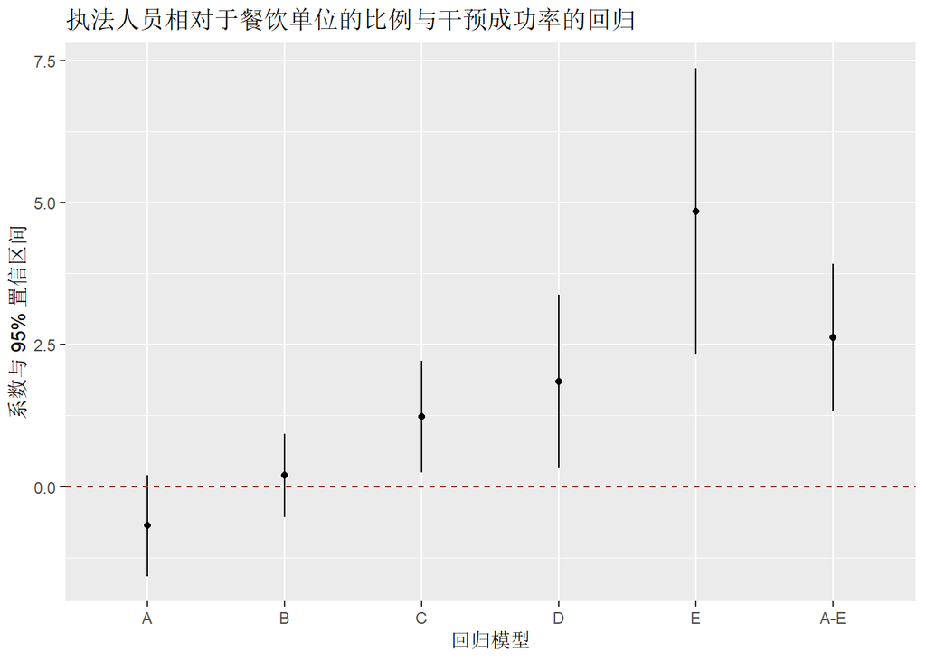

```r
plot8 <- ggplot(regression_table2, aes(x=factor(Variable,labels = c("A","B","C","D","E","A-E")),
                              y=Estimate,ymin=LowerCI,ymax=UpperCI))+geom_point()+geom_linerange()+labs(x="回归模型",y="系数与 95% 置信区间",title = "执法人员相对于餐饮单位的比例与干预成功率的回归")+geom_hline(yintercept = 0,lty="dashed",col="brown")

plot8
```

# 第二部分：主要发现和建议

## 对风险较高的餐饮单位进行的干预效果更好

我们首先检查所有餐饮单位实现干预的百分比分布情况，该分布图呈负偏斜（或左偏斜）。考虑到倾斜度，中位数比平均值更适合代表各地方当局的平均值。根据计算，中位数为 90.82，标准差为 12.38。

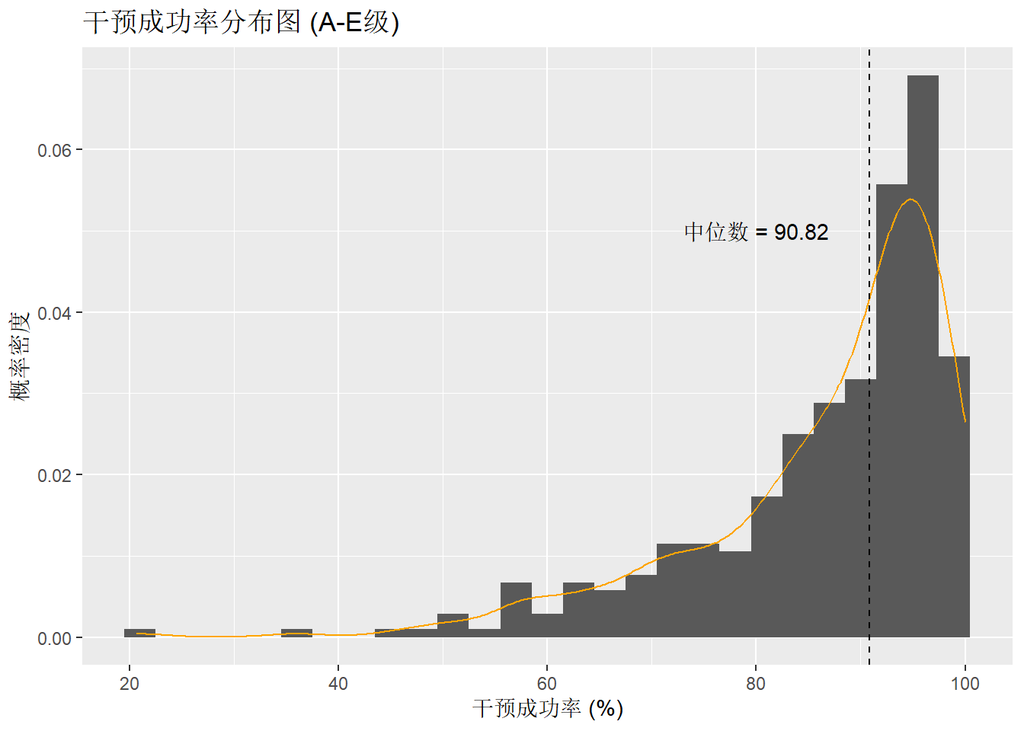

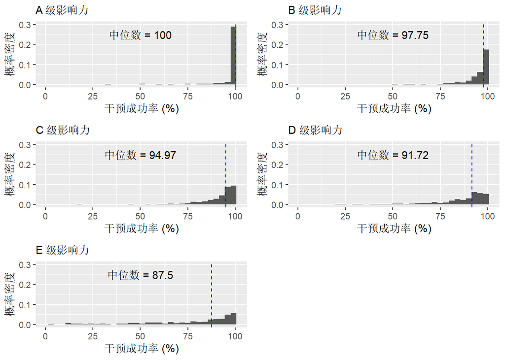

## 执法人员数量与干预成功率之间的关系较弱

在建立回归模型之前，我们使用散点图来直观显示相关变量之间的关系。无论是整体衡量，还是按 A、B、C、D 和 E 类分别衡量，“干预成功率”与“执法人员数量”本身之间似乎都没有明显的关系，**除 D 评级单位外，蓝色拟合线都是近似水平的**。为了更好地观察这些过于集中的数据点，同时减轻异常值的影响，我们将连续变量“执法人员数量”切分为四个区间，并绘制了额外的 D 评级箱形图。

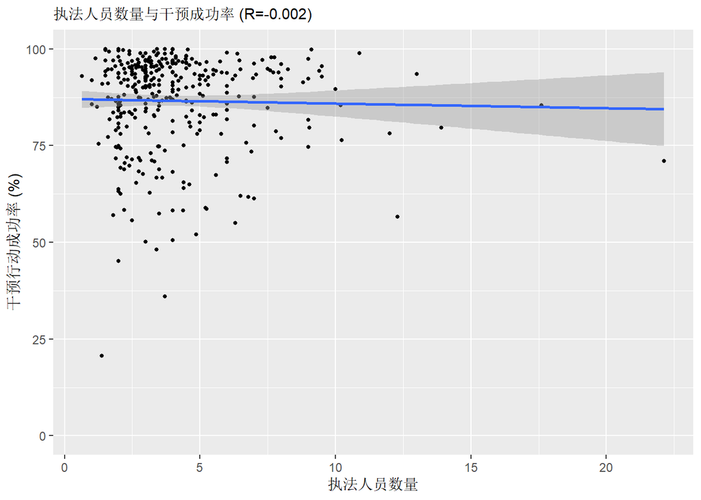

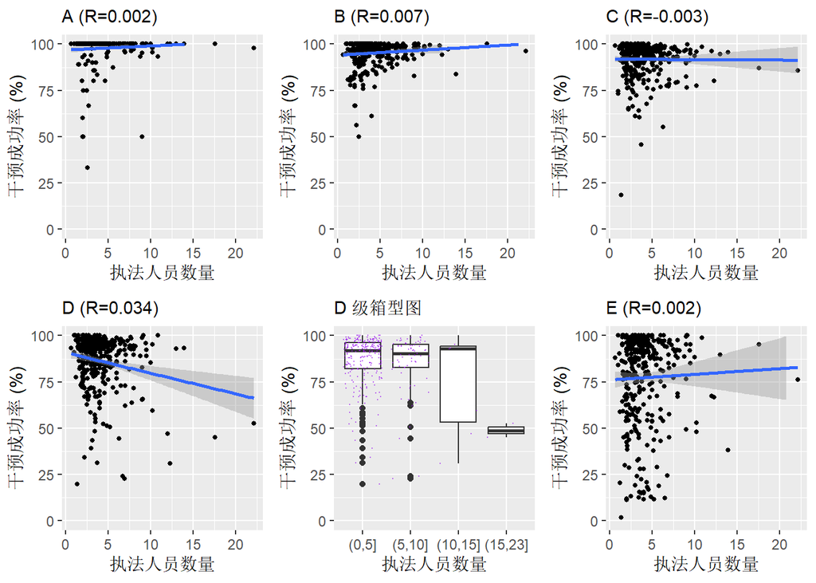

以下是执法人员数量分别对所有A、B、C、D 和 E 评级的餐饮单位的干预成功率的回归系数图。

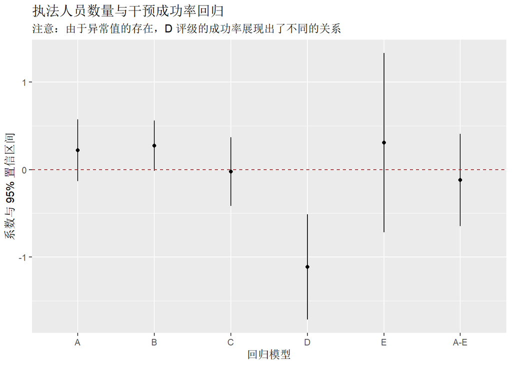

同样，在建立回归模型之前，我们使用散点图来直观地显示各种关系。就整体干预措施的成功率而言，“执法人员相对于 1000 家餐饮单位的比例”比“执法人员数量”具有更明显的积极影响。与现实情况相符，即使两个地方当局的执法人员总数相同，但负责更多餐饮单位的地方当局的执法人员人均工作量会更大，这可能导致执法干预成功率的下降。

就被评为 A、B、C、D 和 E 级的单位而言，**执法人员相对于 1000 家餐饮单位的比例对风险较低的单位（被评为 C、D 和 E 级）的干预效果似乎更强**。如图所示，蓝色拟合线从 A 到 E 越来越陡。

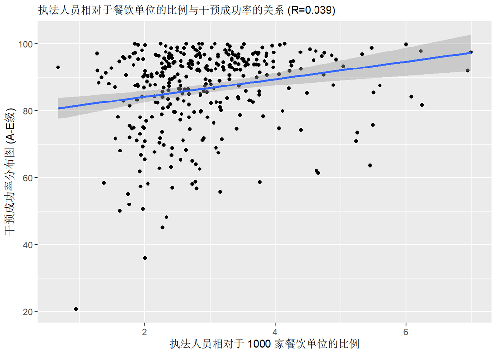

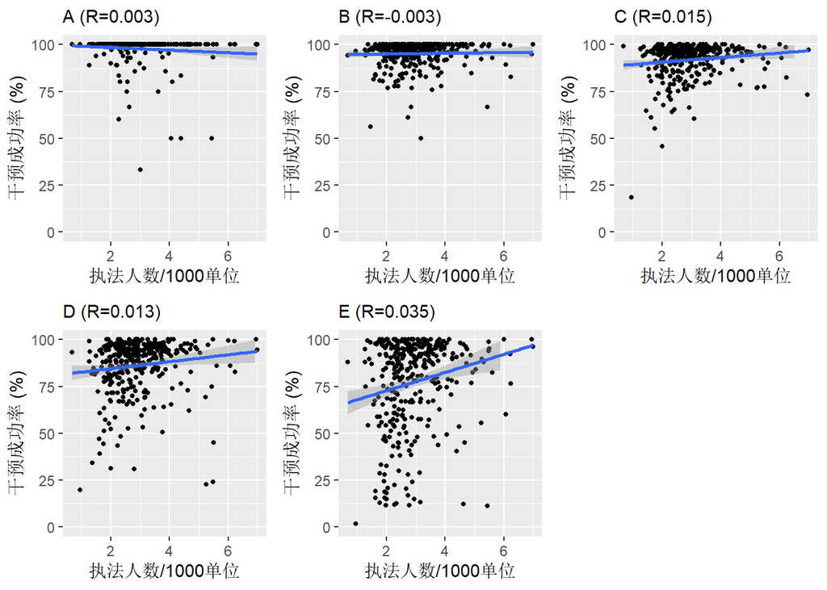

以上图表展示了执法人员相对于 1000 家餐饮单位的比例与各级别（A、B、C、D和E）餐饮单位对政府干预措施的成功率之间的关系。

我们发现，当我们增加执法人员相对于 1000 家餐饮单位的比例时，并不是所有级别的餐饮单位对政府干预的成功率都有所提高。

**对于被认为风险更高的 A 级和 B 级单位，增加执法人员的数量对干预成功率的提高没有太大的影响**。这可能是由于地方当局对于该类单位已经进行了重点关注，干涉措施近似于饱和状态。在近饱和状态下，增加执法人员相对于餐饮单位的比例并不会显著提高执法行动的干预成功率。

**对于被认为风险较低的 C 级、D 级和 E 级单位，增加执法人员的数量会显著提高干预成功率**。这可能是由于这些较低风险的单位在资源有限的情况下没有成为政府干预的首要目标。因此，对于这类单位，在资源充足的情况下可以尝试通过提高执法人员相对于餐饮单位的比例来提高干预成功率。

**建议**：由于提高“执法人员相对于餐饮单位的比例”比单纯提高“执法人员数量”更具备实际价值，但本报告中并未涉及关于最优人员配比的讨论。因此，我们建议未来的研究应探讨如何有效配置执法人员，以便最大程度地提高干预措施的成功率。这样的研究结果将有助于地方当局做出更有效的资源分配决策。

## 执法人员相对于 1000 家餐饮单位的比例与干预成功率的回归分析

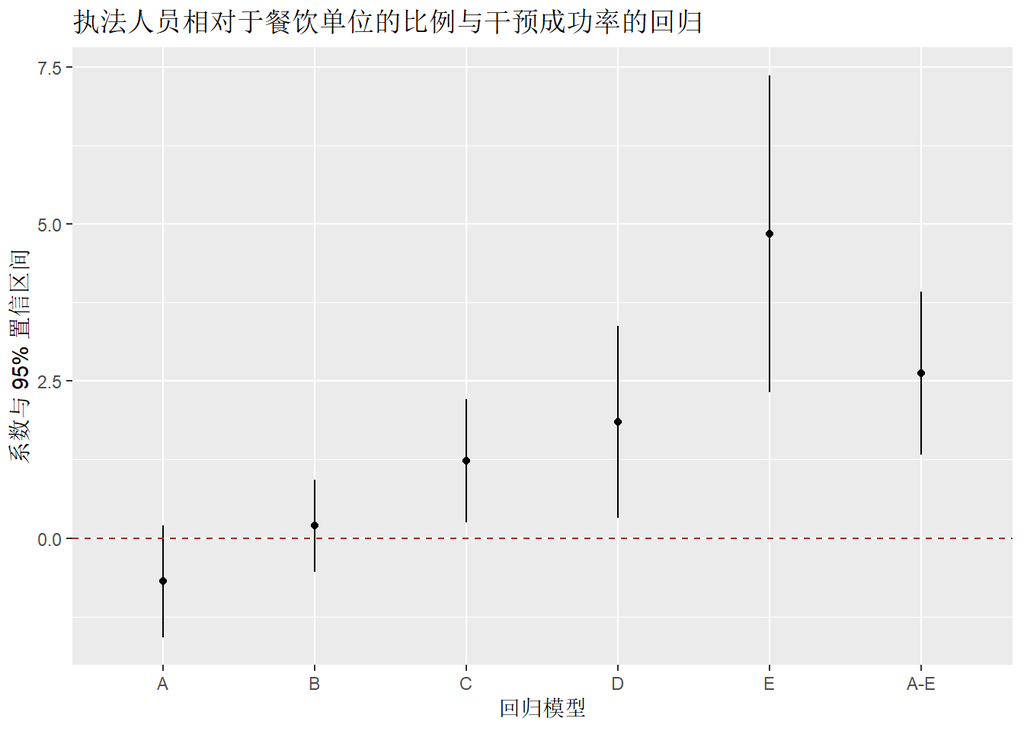

# 附录：数据字典

| 变量名称 | 变量含义 |
| --- | --- |
| Country | 地方当局所属的国家名称 |
| LAType | 地方当局的类型 |
| LAName | 地方当局的名称 |
| Totalestablishments(includingnotyetrated&outside) | 截至 2020 年 3 月 31 日，地方当局报告注册（或批准）的餐饮单位数量 |
| Establishmentsnotyetratedforintervention | 尚未进行食品卫生风险评级（如新企业等）的餐饮单位数量 |
| Establishmentsoutsidetheprogramme | 不在《卫生和食品安全法》管辖范围内的餐饮单位数量 |
| Total%ofBroadlyCompliantestablishmentsratedA-E | 在《食品卫生评级计划》中获得3分（基本满意）或以上卫生评级的餐饮单位的百分比 |
| Total%ofBroadlyCompliantestablishments(includingnotyetrated) | 在《食品卫生评级计划》中获得3分（基本满意）或以上卫生评级的餐饮单位的百分比（包括尚未进行评级的餐饮单位） |
| Total%ofBroadlyCompliantestablishments-A | 在《食品卫生评级计划》中获得3分（基本满意）或以上卫生评级的餐饮单位，且获得 A 级影响力评级的百分比 |
| Total%ofBroadlyCompliantestablishments-B | 在《食品卫生评级计划》中获得3分（基本满意）或以上卫生评级的餐饮单位，且获得 B 级影响力评级的百分比 |
| Total%ofBroadlyCompliantestablishments-C | 在《食品卫生评级计划》中获得3分（基本满意）或以上卫生评级的餐饮单位，且获得 C 级影响力评级的百分比 |
| Total%ofBroadlyCompliantestablishments-D | 在《食品卫生评级计划》中获得3分（基本满意）或以上卫生评级的餐饮单位，且获得 D 级影响力评级的百分比 |
| Total%ofBroadlyCompliantestablishments-E | 在《食品卫生评级计划》中获得3分（基本满意）或以上卫生评级的餐饮单位，且获得 E 级影响力评级的百分比 |
| Aratedestablishments | 影响力分数大于92的餐饮单位数量，被视为对公共健康的潜在影响力最大，其干预频率至少为每6个月一次 |
| Bratedestablishments | 影响力分数在72到91之间的餐饮单位数量，其干预频率至少为每12个月一次 |
| Cratedestablishments | 影响力分数在52到71之间的餐饮单位数量，其干预频率至少为每18个月一次 |
| Dratedestablishments | 影响力分数在31到51之间的餐饮单位数量，其干预频率至少为每24个月一次 |
| Eratedestablishments | 影响力分数小于30的餐饮单位数量，被视为对公共健康的潜在影响力最小，其干预频率为每3年一次，或采用其他执法措施 |
| Total%ofInterventionsachieved(premisesratedA-E) | 根据《食品卫生干预情况评级》计算出的干预行动完成率 |
| Total%ofInterventionsachieved-premisesratedA | 根据《食品卫生干预情况评级》计算出的针对影响力评级为 A 的单位的干预行动完成率 |
| Total%ofInterventionsachieved-premisesratedB | 根据《食品卫生干预情况评级》计算出的针对影响力评级为 B 的单位的干预行动完成率级 |
| Total%ofInterventionsachieved-premisesratedC | 根据《食品卫生干预情况评级》计算出的针对影响力评级为 C 的单位的干预行动完成率 |
| Total%ofInterventionsachieved-premisesratedD | 根据《食品卫生干预情况评级》计算出的针对影响力评级为 D 的单位的干预行动完成率 |
| Total%ofInterventionsachieved-premisesratedE | 根据《食品卫生干预情况评级》计算出的针对影响力评级为 E 的单位的干预行动完成率 |
| Total%ofInterventionsachieved-premisesnotyetrated | 根据《食品卫生干预情况评级》计算出的尚未进行影响力评级单位的干预行动完成率 |
| Totalnumberofestablishmentssubjecttoformalenforcementactions-Voluntaryclosure | 因未能符合《卫生和食品安全法》而被自愿关闭的餐饮单位总数 |
| Totalnumberofestablishmentssubjecttoformalenforcementactions-Seizure,detention&surrenderoffood | 因未能符合《卫生和食品安全法》而被扣押和上缴食品的餐饮单位总数 |
| Totalnumberofestablishmentssubjecttoformalenforcementactions-Suspension/revocationofapprovalorlicence | 因未能符合《卫生和食品安全法》而被暂停/撤销批准或许可的餐饮单位总数 |
| Totalnumberofestablishmentssubjecttoformalenforcementactions-Hygieneemergencyprohibitionnotice | 因未能符合《卫生和食品安全法》而被下发卫生紧急禁令通知的餐饮单位总数 |
| Totalnumberofestablishmentssubjecttoformalenforcementactions-Prohibitionorder | 因未能符合《卫生和食品安全法》而被下达禁令的餐饮单位总数 |
| Totalnumberofestablishmentssubjecttoformalenforcementactions-Simplecaution | 因未能符合《卫生和食品安全法》而被下达简单指控的餐饮单位总数 |
| Totalnumberofestablishmentssubjecttoformalenforcementactions-Hygieneimprovementnotices | 因未能符合《卫生和食品安全法》而被下发卫生改进通知的餐饮单位总数 |
| Totalnumberofestablishmentssubjecttoformalenforcementactions-Remedialaction&detentionnotices | 因未能符合《卫生和食品安全法》而被下发补救行动和扣留通知的餐饮单位总数 |
| TotalnumberofestablishmentssubjecttoWrittenwarnings | 因未能符合《卫生和食品安全法》而被下发书面警告的餐饮单位总数 |
| Totalnumberofestablishmentssubjecttoformalenforcementactions-Prosecutionsconcluded | 因未能符合《卫生和食品安全法》而被起诉的餐饮单位总数 |
| ProfessionalFullTimeEquivalentPosts-occupied * | 在食品卫生方面的执法人员数量 |